# Quarto-Report

Elemente, Konventionen und Beispielinhalte

Was ist in Quarto-Berichten möglich? Wie sehen Quarto-Berichte aus?

Autor:innen

Zugehörigkeit

Flavian Imlig

Bildungsplanung des Kantons Zürich

Sarah Gerhard

Bildungsplanung des Kantons Zürich

Veröffentlichungsdatum

21. März 2024

Zusammenfassung

Abstract folgt hier

# 1 Markdown

Quarto-Dokumente sind grundsätzlich in Markdown verfasst.

**Empfehlung**

Elemente und Syntax gemäss https://www.markdownguide.org/basic-syntax verwenden.

## 1.1 Absätze

Um Absätze zu erstellen, verwende eine Leerzeile zwischen zwei Absätzen.

```markdown
Lorem ipsum dolor sit amet, consectetuer adipiscing elit.

Nulla consequat massa quis enim.
```

Lorem ipsum dolor sit amet, consectetuer adipiscing elit.

Nulla consequat massa quis enim.

## 1.2 Zeilenumbrüche

Um einen Zeilenumbruch bzw. eine neue Zeile zu erzeugen, beende eine Zeile mit zwei oder mehr Leerzeichen.

```markdown
Lorem ipsum dolor sit amet, consectetuer adipiscing elit.
Nulla consequat massa quis enim.
```

Lorem ipsum dolor sit amet, consectetuer adipiscing elit.  
Nulla consequat massa quis enim.

## 1.3 Textauszeichnungen

### 1.3.1 Kursiv und Fett

Um Text kursiv zu setzen, einen *Asterisk* oder einen *Unterstrich* vor und nach einem Wort oder Satz einsetzen. Um die Mitte eines Wortes kursiv zu setzen, einen Ast*er*isk ohne Leerzeichen um die Buchstaben einfügen.

```markdown
*Asterisk*
_Unterstrich_
Ast*er*isk
```

Um Text fett zu setzen, zwei **Asterisks** oder zwei **Unterstriche** vor und nach einem Wort oder Satz einsetzen. Um die Mitte eines Wortes fett zu setzen, zwei Ast**er**isks ohne Leerzeichen um die Buchstaben einfügen.

```markdown
**Asterisk**
__Unterstrich__
Ast**er**isk
```

Um Text fett und kursiv zu setzen, drei *Asterisks* oder drei *Unterstriche* vor und nach einem Wort oder Satz einsetzen. Um die Mitte eines Wortes fett zu setzen, drei Ast*er*isks ohne Leerzeichen um die Buchstaben einfügen.

```markdown
***Asterisk***
___Unterstrich___
Ast***er***isk
```

### 1.3.2 Durchgestrichen

Um Wörter durchgestrichen darzustellen, zwei Tilde-Symbole vor und nach den Wörtern setzen.

```markdown
~~Tilde-Symbole~~
```

### 1.3.3 Hoch- und Tiefgestellt

Einige Markdown-Prozessoren ermöglichen die Verwendung von Hoch- Tiefstellung

Um ein oder mehrere Zeichen hochgestellt zu positionieren, ein <sup>Caret-Symbol</sup> davor und danach verwenden. (z.B. X<sup>2</sup>)

```markdown
^Caret-Symbol^
X^2^
```

Um ein oder mehrere Zeichen tiefgestellt zu positionieren, ein <sub>Tilde-Symbol</sub> davor und danach verwenden. (z.B. H<sub>2</sub>O)

```markdown
~Tilde-Symbol~
H~2~O
```

### 1.3.4 Hervorgehoben

Einige Markdown-Prozessoren ermöglichen es, Text besonders hervorzuheben.

Um Wörter hervorzuheben, zwei ==Gleichheitszeichen== vor und nach den Wörtern verwenden.

**Vorsicht**

Unser Setup mit RStudio, Pandoc und Quarto ermöglicht keine Hervorhebungen!

## 1.4 Listen

- First item
- Second item
- Third item
  - Indented item
  - Indented item
- Fourth item

```markdown
- First item
- Second item
- Third item
    - Indented item
    - Indented item
- Fourth item
```

1. First item
2. Second item
3. Third item
   1. Indented item
   2. Indented item
4. Fourth item

```markdown
1. First item
2. Second item
3. Third item
    a. Indented item
    b. Indented item
4. Fourth item
```

Einige Markdown-Prozessoren ermöglichen es, Definitionslisten mit Begriffen und den dazugehörigen Definitionen zu erstellen. Um eine Definitionsliste zu erstellen, den Begriff in die erste Zeile eingeben und in die nächste Zeile einen Doppelpunkt, gefolgt von einem Leerzeichen und der Definition, schreiben.

**First Term**

This is the definition of the first term.

**Second Term**

This is one definition of the second term.

This is another definition of the second term.

```markdown
First Term
: This is the definition of the first term.

Second Term
: This is one definition of the second term.
: This is another definition of the second term.
```

## 1.5 Blockzitate

> Um ein Blockzitat zu erstellen, ein `>` vor einem Absatz einfügen.

```markdown
> Um ein Blockzitat zu erstellen, ein `>` vor einem Absatz einfügen.
```

> Blockzitate können mehrere Absätze enthalten.

> In den Leerzeilen zwischen den Absätzen ein `>` einfügen.

```markdown
> Blockzitate können mehrere Absätze enthalten.
>
> In den Leerzeilen zwischen den Absätzen ein `>` einfügen.
```

Blockzitate können andere Markdown-formatierte Elemente enthalten. Es können nicht alle Elemente verwendet werden. Man muss experimentieren, um herauszufinden, welche Elemente funktionieren.

## 1.6 Links

Um eine URL oder E-Mail-Adresse schnell in einen Link zu verwandeln, schliesse sie in spitze Klammern ein.

https://www.zh.ch/de/bildungsdirektion.html  
bildungsplanung@bi.zh.ch

```markdown
<https://www.zh.ch/de/bildungsdirektion.html>
<bildungsplanung@bi.zh.ch>
```

Einige Markdown-Prozessoren verwandeln URLs automatisch in Links, so dass keine spitze Klammern verwendet werden müssen.

**Vorsicht**

Unser Setup mit RStudio, Pandoc und Quarto erstellt nicht automatisch Links! Es müssen also spitze Klammern verwendet werden.

Um einen Link zu erstellen, den Linktext in eckige Klammern einschliessen und die URL in Klammern anschliessen.

[Bildungsplanung des Kantons Zürich](https://www.zh.ch/de/bildungsdirektion/generalsekretariat-der-bildungsdirektion/bildungsplanung.html)

```markdown
[Bildungsplanung des Kantons Zürich](https://www.zh.ch/de/bildungsdirektion/generalsekretariat-der-bildungsdirektion/bildungsplanung.html)
```

In HTML-Dokumenten ist es teilweise sinnvoll, dass Links in einem neuen Tab oder Fenster geöffnet werden. Die Markdown-Syntax für Links erlaubt es nicht, ein sogenanntes Zielattribut anzugeben. In Quarto-Dokumenten kann aber HTML verwendet werden, um solche Links zu erstellen.

[Bildungsplanung des Kantons Zürich](https://www.zh.ch/de/bildungsdirektion/generalsekretariat-der-bildungsdirektion/bildungsplanung.html)

```html
<a href="https://www.zh.ch/de/bildungsdirektion/generalsekretariat-der-bildungsdirektion/bildungsplanung.html" target="_blank">Bildungsplanung des Kantons Zürich</a>
```

Innerhalb von Quarto-Dokumenten kann auf sogenannte IDs verlinkt werden.

vgl. Kapitel 2.2  
vgl. Querverweise

```markdown
vgl. @sec-references-internal
vgl. [Querverweise](#sec-references-internal)
```

# 2 Titelhierarchien

Es können im Prinzip beliebig viele Überschriftsebenen verwendet werden.

Im Design werden vier Ebenen berücksichtigt.

## 2.1 Nummerierung

Im YAML-Header kann angegeben werden, ob die Überschriften nummeriert werden sollen (`number-sections`), und bis zu welcher Tiefe (`number-depth`).

**Empfehlung**

```yaml
number-sections: true
number-depth: 3
```

## 2.2 Querverweise

### 2.2.1 Anker setzen

Um ein Objekt mit Querverweisen zu referenzieren, ist empfohlen einen entsprechenden Anker zu setzen.

```markdown
### Anker setzen {#sec-anchor}
```

### 2.2.2 Anker ansprechen

Ein solcher Anker (Kapitel 2.2.1) kann dann einfach referenziert werden.

```markdown
@sec-anchor
[eigener Text](#sec-anchor)
```

## 2.3 Beispielinhalte

Lorem ipsum dolor sit amet, consectetuer adipiscing elit. Aenean commodo ligula eget dolor. Aenean massa. Cum sociis natoque penatibus et magnis dis parturient montes, nascetur ridiculus mus. Donec quam felis, ultricies nec, pellentesque eu, pretium quis, sem.

Nulla consequat massa quis enim. Donec pede justo, fringilla vel, aliquet nec, vulputate eget, arcu. In enim justo, rhoncus ut, imperdiet a, venenatis vitae, justo. Nullam dictum felis eu pede mollis pretium. Integer tincidunt. Cras dapibus. Vivamus elementum semper nisi. Aenean vulputate eleifend tellus.

### 2.3.1 Überschrift 3

Lorem ipsum dolor sit amet, consectetuer adipiscing elit. Aenean commodo ligula eget dolor. Aenean massa. Cum sociis natoque penatibus et magnis dis parturient montes, nascetur ridiculus mus. Donec quam felis, ultricies nec, pellentesque eu, pretium quis, sem.

Nulla consequat massa quis enim. Donec pede justo, fringilla vel, aliquet nec, vulputate eget, arcu. In enim justo, rhoncus ut, imperdiet a, venenatis vitae, justo. Nullam dictum felis eu pede mollis pretium. Integer tincidunt. Cras dapibus. Vivamus elementum semper nisi. Aenean vulputate eleifend tellus.

#### Überschrift 4

Lorem ipsum dolor sit amet, consectetuer adipiscing elit. Aenean commodo ligula eget dolor. Aenean massa. Cum sociis natoque penatibus et magnis dis parturient montes, nascetur ridiculus mus. Donec quam felis, ultricies nec, pellentesque eu, pretium quis, sem.

Nulla consequat massa quis enim. Donec pede justo, fringilla vel, aliquet nec, vulputate eget, arcu. In enim justo, rhoncus ut, imperdiet a, venenatis vitae, justo. Nullam dictum felis eu pede mollis pretium. Integer tincidunt. Cras dapibus. Vivamus elementum semper nisi. Aenean vulputate eleifend tellus.

### 2.3.2 Überschrift 3

#### Überschrift 4

Lorem ipsum dolor sit amet, consectetuer adipiscing elit. Aenean commodo ligula eget dolor. Aenean massa. Cum sociis natoque penatibus et magnis dis parturient montes, nascetur ridiculus mus. Donec quam felis, ultricies nec, pellentesque eu, pretium quis, sem.

Nulla consequat massa quis enim. Donec pede justo, fringilla vel, aliquet nec, vulputate eget, arcu. In enim justo, rhoncus ut, imperdiet a, venenatis vitae, justo. Nullam dictum felis eu pede mollis pretium. Integer tincidunt. Cras dapibus. Vivamus elementum semper nisi. Aenean vulputate eleifend tellus.

# 3 Abbildungen

**Empfehlung**

Möglichst immer nummerierte Abbildungen mit Datenangabe verwenden (Kapitel 3.1)

## 3.1 Standard-Abbildung BM

### 3.1.1 komplett

Lorem ipsum dolor sit amet, consectetuer adipiscing elit. Aenean commodo ligula eget dolor. Aenean massa. Cum sociis natoque penatibus et magnis dis parturient montes, nascetur ridiculus mus. Donec quam felis, ultricies nec, pellentesque eu, pretium quis, sem.

Abbildung 1: Titel einer Standard-Abbildung Bildungsmonitoring

Abbildungsbeschriftung zweite Ebene

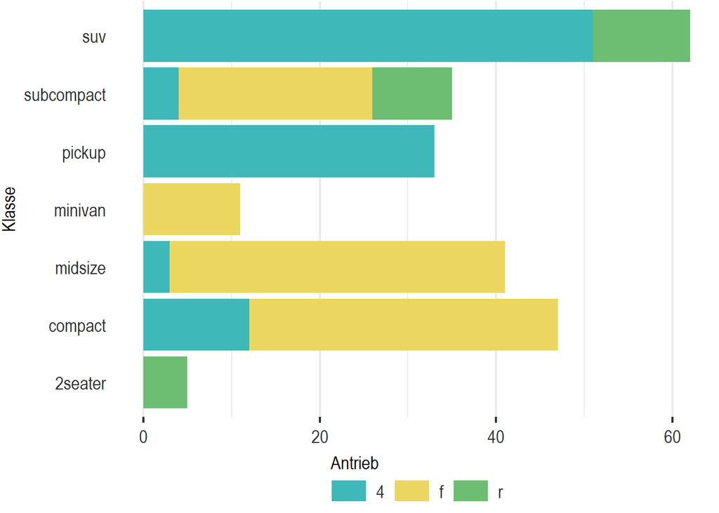

Nulla consequat massa quis enim. Donec pede justo, fringilla vel, aliquet nec, vulputate eget, arcu. In enim justo, rhoncus ut, imperdiet a, venenatis vitae, justo. Nullam dictum felis eu pede mollis pretium. Integer tincidunt. Cras dapibus. Vivamus elementum semper nisi. Aenean vulputate eleifend tellus.

````markdown
::: {#fig-plotbm1 .figure_bm}
[Abbildungsbeschriftung zweite Ebene]{.figure-subcaption}

\```{r}
#| echo: false
plot_1
\```

[Daten: Bildungsplanung des Kantons Zürich]{.figure-source}

Titel einer Standard-Abbildung Bildungsmonitoring
:::
````

Referenzierung der Abbildung als normaler Querverweis: vgl. Abbildung 1

```markdown
@fig-plotbm1
```

### 3.1.2 ohne zweite Beschriftung

Lorem ipsum dolor sit amet, consectetuer adipiscing elit. Aenean commodo ligula eget dolor. Aenean massa. Cum sociis natoque penatibus et magnis dis parturient montes, nascetur ridiculus mus. Donec quam felis, ultricies nec, pellentesque eu, pretium quis, sem.

Abbildung 2: Titel einer Standard-Abbildung Bildungsmonitoring

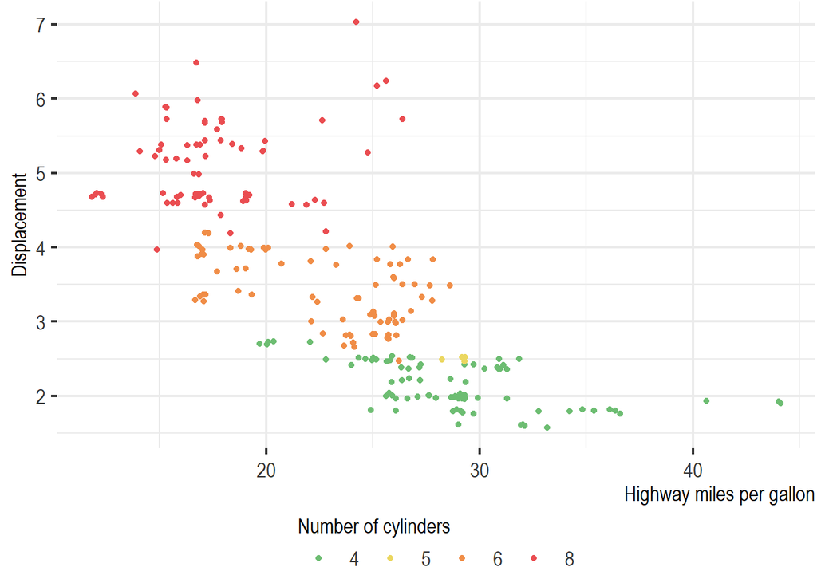

Daten: Bildungsplanung des Kantons Zürich

Nulla consequat massa quis enim. Donec pede justo, fringilla vel, aliquet nec, vulputate eget, arcu. In enim justo, rhoncus ut, imperdiet a, venenatis vitae, justo. Nullam dictum felis eu pede mollis pretium. Integer tincidunt. Cras dapibus. Vivamus elementum semper nisi. Aenean vulputate eleifend tellus.

````markdown
::: {#fig-plotbm2 .figure_bm}
\```{r}
#| echo: false
plot_2
\```

[Daten: Bildungsplanung des Kantons Zürich]{.figure-source}

Titel einer Standard-Abbildung Bildungsmonitoring
:::
````

## 3.2 einfache Abbildung

Lorem ipsum dolor sit amet, consectetuer adipiscing elit. Aenean commodo ligula eget dolor. Aenean massa. Cum sociis natoque penatibus et magnis dis parturient montes, nascetur ridiculus mus. Donec quam felis, ultricies nec, pellentesque eu, pretium quis, sem.

Einfache Abbildung mit `fig-cap`

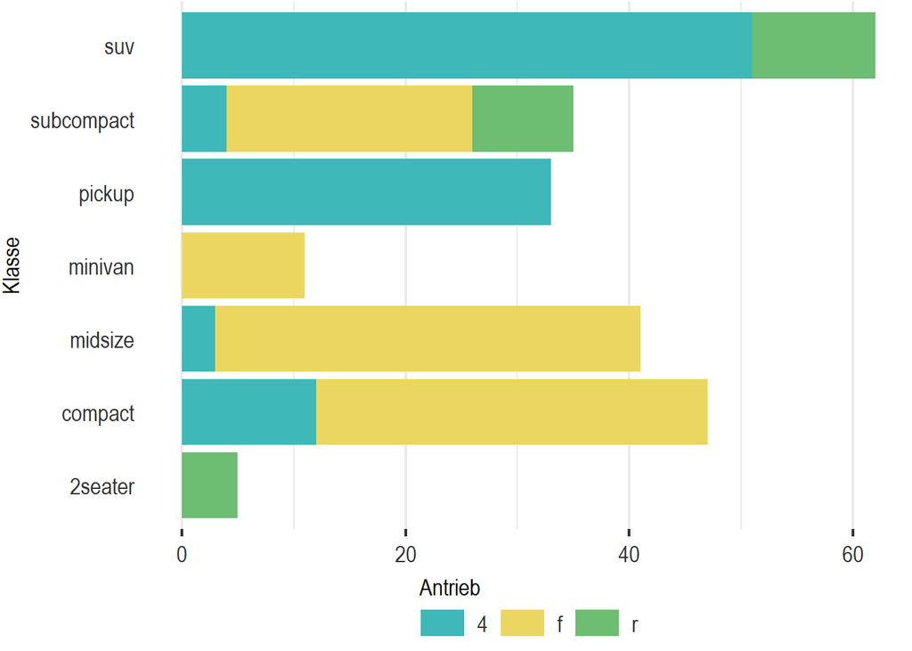

Nulla consequat massa quis enim. Donec pede justo, fringilla vel, aliquet nec, vulputate eget, arcu. In enim justo, rhoncus ut, imperdiet a, venenatis vitae, justo. Nullam dictum felis eu pede mollis pretium. Integer tincidunt. Cras dapibus. Vivamus elementum semper nisi. Aenean vulputate eleifend tellus.

```r
#| label: plot_simple_caption
#| fig-cap: Einfache Abbildung mit `fig-cap`
plot_1
```

# 4 Tabellen

Grundsätzlich müssen Tabellen in der Markdown-Syntax vorliegen (vgl. https://www.markdownguide.org/extended-syntax/#tables). Allerdings gibt es verschiedene Möglichkeiten, eine Tabelle in diesem Format zu generieren. Ausserdem fehlen bei einer einfachen Tabelle meistens die Metadaten (vgl. Kapitel 3.1).

## 4.1 Standard-Tabelle BM

### 4.1.1 komplett

Lorem ipsum dolor sit amet, consectetuer adipiscing elit. Aenean commodo ligula eget dolor. Aenean massa. Cum sociis natoque penatibus et magnis dis parturient montes, nascetur ridiculus mus. Donec quam felis, ultricies nec, pellentesque eu, pretium quis, sem.

Tabelle 1: Titel einer Standard-Tabelle Bildungsmonitoring

(a) Tabellenbeschriftung zweite Ebene

| Kanton | Wert | Kategorie |
| --- | --- | --- |
| ZH | 73 | X |
| BE | 15 | W |
| AG | 70 | V |
| LU | 35 | J |
| GR | 16 | J |
| GL | 6 | I |
| SG | 49 | G |
| TG | 46 | K |
| SZ | 15 | T |
| ZG | 80 | P |

Daten: Bildungsplanung des Kantons Zürich

Nulla consequat massa quis enim. Donec pede justo, fringilla vel, aliquet nec, vulputate eget, arcu. In enim justo, rhoncus ut, imperdiet a, venenatis vitae, justo. Nullam dictum felis eu pede mollis pretium. Integer tincidunt. Cras dapibus. Vivamus elementum semper nisi. Aenean vulputate eleifend tellus.

## 4.2 einfache Tabelle

````markdown
```{r}
#| label: tbl-simple
#| tbl-cap: "Titel der einfachen Tabelle (linksbündig)"

knitr::kable(tbl)
```
````

Tabelle 2: Titel der einfachen Tabelle (linksbündig)

| Kanton | Wert | Kategorie |
| --- | --- | --- |
| ZH | 73 | X |
| BE | 15 | W |
| AG | 70 | V |
| LU | 35 | J |
| GR | 16 | J |
| GL | 6 | I |
| SG | 49 | G |
| TG | 46 | K |
| SZ | 15 | T |
| ZG | 80 | P |

Ein Verweise auf die Tabelle (Tabelle 2) kann mit `@tbl-simple` eingefügt werden.

### 4.2.1 Markdown-Syntax

```
---------------------------
 Kanton   Wert   Kategorie
-------- ------ -----------
   ZH      73        X

   BE      15        W

   AG      70        V

   LU      35        J

   GR      16        J

   GL      6         I

   SG      49        G

   TG      46        K

   SZ      15        T

   ZG      80        P
---------------------------
```

## 4.3 Tabelle mit Filter- und Sortier-Funktionen

Das package `DT` ermöglicht es, R-Datenobjekte als Tabellen in HTML-Seiten darzustellen. Diese Tabellen können gefiltert, sortiert, durchsucht und auf mehrere Seiten verteilt werden.

```r
data_table <- mtcars %>%
    mutate(Modell = rownames(.),
           across(c(cyl, am, gear), as.factor)) %>%
    select(Modell, Zylinder = cyl, Hubraum = disp, PS = hp, Gewicht = wt,
           manuell = am, `Gänge` = gear) %>%
    arrange(Modell)

DT::datatable(data_table, rownames = F, filter = "top",
              caption = "Motor Trend Car Road Tests, Motor Trend magazine 1974")
```

| Modell | Zylinder | Hubraum | PS | Gewicht | manuell | Gänge |
| --- | --- | --- | --- | --- | --- | --- |
| AMC Javelin | 8 | 304 | 150 | 3.435 | 0 | 3 |
| Cadillac Fleetwood | 8 | 472 | 205 | 5.25 | 0 | 3 |
| Camaro Z28 | 8 | 350 | 245 | 3.84 | 0 | 3 |
| Chrysler Imperial | 8 | 440 | 230 | 5.345 | 0 | 3 |
| Datsun 710 | 4 | 108 | 93 | 2.32 | 1 | 4 |
| Dodge Challenger | 8 | 318 | 150 | 3.52 | 0 | 3 |
| Duster 360 | 8 | 360 | 245 | 3.57 | 0 | 3 |
| Ferrari Dino | 6 | 145 | 175 | 2.77 | 1 | 5 |
| Fiat 128 | 4 | 78.7 | 66 | 2.2 | 1 | 4 |
| Fiat X1-9 | 4 | 79 | 66 | 1.935 | 1 | 4 |

[output cut: 22 more lines]

## 4.4 Tabelle mit `gt`

Das Package [`gt`](https://gt.rstudio.com/) ermöglicht gut formatierte Tabellen mit komplexerer Struktur. Die gt-Philosophie: Tabellen werden mit einem zusammenhängenden Satz von Tabellenteilen konstruiert. Dazu gehören der Tabellenkopf, der Stub, die Spaltenbeschriftungen und Schlüsselspaltenbeschriftungen, der Tabellenkörper und die Tabellenfußzeile.

````markdown
```{r}
#| label: tbl-gt
#| tbl-cap: "Kennwerte zur Grösse der Schuleinheiten nach Sekundarschulvariante"

data_table %>%
    gt::gt() %>%
    gt:: tab_spanner(label = text$sus, columns = names(nm_cols)) %>%
    # gt::tab_header(title = text$title) %>%
    gt::tab_source_note(text$source)
```
````

Tabelle 3: Kennwerte zur Grösse der Schuleinheiten nach Sekundarschulvariante

| Jahr | Sekundarschulvariante | Anzahl Schulen | Anzahl Schülerinnen und Schüler Mittelwert | Anzahl Schülerinnen und Schüler Minimum | Anzahl Schülerinnen und Schüler Median | Anzahl Schülerinnen und Schüler Maximum |
| --- | --- | --- | --- | --- | --- | --- |
| 2009/10 | A | 32 | 299 | 84 | 275 | 547 |
| 1994/95 | C | 38 | 370 | 210 | 342 | 562 |
| 1997/98 | C | 54 | 371 | 88 | 446 | 596 |
| 2007/08 | A | 42 | 392 | 97 | 402 | 566 |
| 2007/08 | B | 69 | 335 | 58 | 331 | 562 |
| 2005/06 | B | 83 | 351 | 118 | 402 | 517 |
| 2010/11 | C | 38 | 254 | 53 | 211 | 506 |
| 2017/18 | C | 78 | 383 | 66 | 404 | 532 |
| 2015/16 | A | 64 | 439 | 225 | 487 | 585 |
| 1993/94 | B | 29 | 368 | 166 | 413 | 572 |

Bildungsplanung des Kantons Zürich, 2023

Verweise auf die Tabelle (Tabelle 3) mit `@tbl-gt` einfügen.

# 5 Tabset/Reiter

## 5.1 Standard

Lorem ipsum dolor sit amet, consectetuer adipiscing elit. Aenean commodo ligula eget dolor. Aenean massa. Cum sociis natoque penatibus et magnis dis parturient montes, nascetur ridiculus mus. Donec quam felis, ultricies nec, pellentesque eu, pretium quis, sem.

**Irgendwas**

Hier folgt irgendein Inhalt.

**Etwas anderes**

Das ist ein anderer Inhalt.

**Definitionen**

Hier finden sich Definitionen.

```markdown
:::{.panel-tabset}

## Irgendwas

Hier folgt irgendein Inhalt.

## Etwas anderes

Das ist ein anderer Inhalt.

## Definitionen

Hier finden sich Definitionen.

:::
```

## 5.2 Klasse `nav-pills`

Die Klasse `.nav-pills` bewirkt, dass der aktive Tab farbig hinterlegt wird.

**Irgendwas**

Hier folgt irgendein Inhalt.

**Etwas anderes**

Das ist ein anderer Inhalt.

```markdown
::: {.panel-tabset .nav-pills}
## Irgendwas

Hier folgt irgendein Inhalt.

## Etwas anderes

Das ist ein anderer Inhalt.
:::
```

# 6 Meta-Informationen und Parameter

Die Informationen aus dem YAML-Header können im Dokument selbst wieder aufgerufen werden (vgl. https://quarto.org/docs/authoring/variables.html):

Quarto-Report, 21. März 2024 (Vertraulich)

```markdown
{{< meta title >}}, {{< meta date >}}
({{< meta params.classification >}})
```

Innerhalb von `r`-Chunks können zudem die Parameter aus dem YAML-Header abgerufen werden.

```yaml
params:
    classification: "Vertraulich"
```

```r
params$classification
```

```
[1] "Vertraulich"
```